# Normallity_3.3.4

```python
import numpy as np
import pandas as pd
import matplotlib.pyplot as plt
%matplotlib inline
```

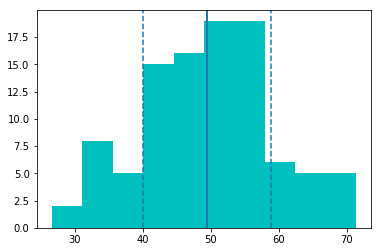

```python
rand1 = np.random.normal(50,10,100)
plt.hist(rand1, color="c")
plt.axvline(rand1.mean(),linestyle="solid", linewidth=2)
plt.axvline(rand1.mean() + rand1.std(), linestyle="dashed")
plt.axvline(rand1.mean() - rand1.std(), linestyle="dashed")
plt.show()
```

Rand1: This normal distribution shows a mean of 50, most data points are close by this value in the range of 100. The standard deviation to both sides shows a distribution of the data, where most data points fall within the first standard deviation to each side of the mean and less and less data points as if falls farther. Therefore the cetnral tendencies of this dataset are useful to discern some information about the variable.

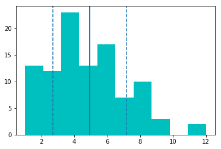

```python
rand2 = np.random.poisson(5,100)
plt.hist(rand2, color="c")
plt.axvline(rand2.mean(),linestyle="solid", linewidth=2)
plt.axvline(rand2.mean() + rand2.std(), linestyle="dashed")
plt.axvline(rand2.mean() - rand2.std(), linestyle="dashed")
plt.show()
```

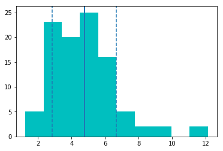

```python
rand3 = np.random.gamma(5,1,100)
plt.hist(rand3, color="c")
plt.axvline(rand3.mean(),linestyle="solid", linewidth=2)
plt.axvline(rand3.mean() + rand3.std(), linestyle="dashed")
plt.axvline(rand3.mean() - rand3.std(), linestyle="dashed")
plt.show()
```

Rand3: We see a similar data distribution in this histogram as on the poisso histogram. And central tendacy data such as the mean should be use with caution.

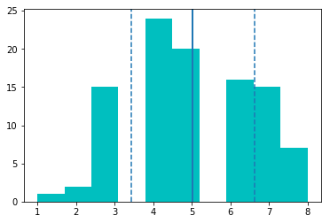

```python
rand4 = np.random.binomial(10,0.5,100)
plt.hist(rand4, color="c")
plt.axvline(rand4.mean(),linestyle="solid", linewidth=2)
plt.axvline(rand4.mean() + rand4.std(), linestyle="dashed")
plt.axvline(rand4.mean() - rand4.std(), linestyle="dashed")
plt.show()
```

Rand4: The mean is slightly skewed to the right and it should be with caution if use to measure the central tendecy of the data. The standard deviation can not describe the variance of the dataset accurately due to its not symetric distribution. If the number sample was higher it would most likely resemble a normal distribution.

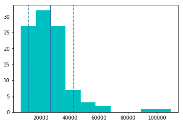

```python
rand5 = np.random.lognormal(10,0.5,100)
plt.hist(rand5, color="c")
plt.axvline(rand5.mean(),linestyle="solid", linewidth=2)
plt.axvline(rand5.mean() + rand5.std(), linestyle="dashed")
plt.axvline(rand5.mean() - rand5.std(), linestyle="dashed")
plt.show()
```

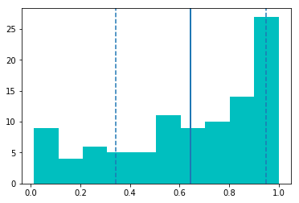

```python
rand6 = np.random.beta(1,0.5,100)
plt.hist(rand6, color="c")
plt.axvline(rand6.mean(),linestyle="solid", linewidth=2)
plt.axvline(rand6.mean() + rand6.std(), linestyle="dashed")
plt.axvline(rand6.mean() - rand6.std(), linestyle="dashed")
plt.show()
```

Rand6. The mean data points are mostly skewed to the left and the mean its not a good representation of the central tendency of this dataset as applies to the standard deviation.

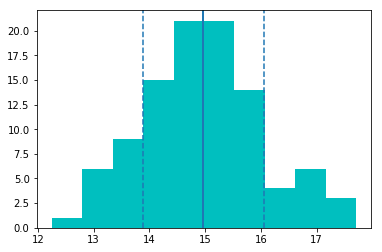

```python
rand7 = np.random.normal(5,0.5,100)
rand8 = np.random.normal(10,1,100)
rand9 = rand7 + rand8
plt.hist(rand9, color="c")
plt.axvline(rand9.mean(),linestyle="solid", linewidth=2)
plt.axvline(rand9.mean() + rand9.std(), linestyle="dashed")
plt.axvline(rand9.mean() - rand9.std(), linestyle="dashed")
plt.show()
```

Rand9. The mean captures the center of the mayority of the datapoints very well, and most data seems to fall whithin the first standard deviation as expected from a normal distributed data points. The mean and STD in this case are useful to describe the central tendency of this variable.